# Risk Factor Analysis

## Outcome Variable

**Outcome Variable:** dead624

## Predictor Variables

**Intervention Variable:** ever_underweight024

**Adjustment Set:**

- sex
- arm
- brthmon
- vagbrth
- hhwealth_quart
- W_mage
- W_mhtcm
- W_mwtkg
- W_mbmi
- W_meducyrs
- W_feducyrs
- W_nrooms
- W_parity
- impsan
- safeh20
- delta_vagbrth
- delta_hhwealth_quart
- delta_W_mage
- delta_W_mhtcm
- delta_W_mwtkg
- delta_W_mbmi
- delta_W_meducyrs
- delta_W_feducyrs
- delta_W_nrooms
- delta_W_parity
- delta_impsan
- delta_safeh20

## Stratifying Variables

The analysis was stratified on these variable(s):

- studyid
- country

## Data Summary

| studyid | country | ever_underweight024 | dead624 | n_cell | n | outcome_variable |
| --- | --- | --- | --- | --- | --- | --- |
| Burkina Faso Zn | BURKINA FASO | 0 | 0 | 4727 | 7163 | dead624 |
| Burkina Faso Zn | BURKINA FASO | 0 | 1 | 18 | 7163 | dead624 |
| Burkina Faso Zn | BURKINA FASO | 1 | 0 | 2397 | 7163 | dead624 |
| Burkina Faso Zn | BURKINA FASO | 1 | 1 | 21 | 7163 | dead624 |
| EE | PAKISTAN | 0 | 0 | 52 | 375 | dead624 |
| EE | PAKISTAN | 0 | 1 | 0 | 375 | dead624 |
| EE | PAKISTAN | 1 | 0 | 319 | 375 | dead624 |
| EE | PAKISTAN | 1 | 1 | 4 | 375 | dead624 |
| GMS-Nepal | NEPAL | 0 | 0 | 151 | 592 | dead624 |
| GMS-Nepal | NEPAL | 0 | 1 | 1 | 592 | dead624 |
| GMS-Nepal | NEPAL | 1 | 0 | 439 | 592 | dead624 |
| GMS-Nepal | NEPAL | 1 | 1 | 1 | 592 | dead624 |
| iLiNS-DOSE | MALAWI | 0 | 0 | 1115 | 1874 | dead624 |
| iLiNS-DOSE | MALAWI | 0 | 1 | 63 | 1874 | dead624 |
| iLiNS-DOSE | MALAWI | 1 | 0 | 632 | 1874 | dead624 |
| iLiNS-DOSE | MALAWI | 1 | 1 | 64 | 1874 | dead624 |
| iLiNS-DYAD-M | MALAWI | 0 | 0 | 755 | 1161 | dead624 |
| iLiNS-DYAD-M | MALAWI | 0 | 1 | 12 | 1161 | dead624 |
| iLiNS-DYAD-M | MALAWI | 1 | 0 | 382 | 1161 | dead624 |
| iLiNS-DYAD-M | MALAWI | 1 | 1 | 12 | 1161 | dead624 |
| JiVitA-3 | BANGLADESH | 0 | 0 | 9924 | 21046 | dead624 |
| JiVitA-3 | BANGLADESH | 0 | 1 | 99 | 21046 | dead624 |
| JiVitA-3 | BANGLADESH | 1 | 0 | 10851 | 21046 | dead624 |
| JiVitA-3 | BANGLADESH | 1 | 1 | 172 | 21046 | dead624 |
| JiVitA-4 | BANGLADESH | 0 | 0 | 2562 | 5433 | dead624 |
| JiVitA-4 | BANGLADESH | 0 | 1 | 13 | 5433 | dead624 |
| JiVitA-4 | BANGLADESH | 1 | 0 | 2822 | 5433 | dead624 |
| JiVitA-4 | BANGLADESH | 1 | 1 | 36 | 5433 | dead624 |
| Keneba | GAMBIA | 0 | 0 | 1486 | 2761 | dead624 |
| Keneba | GAMBIA | 0 | 1 | 20 | 2761 | dead624 |
| Keneba | GAMBIA | 1 | 0 | 1231 | 2761 | dead624 |
| Keneba | GAMBIA | 1 | 1 | 24 | 2761 | dead624 |
| MAL-ED | BANGLADESH | 0 | 0 | 109 | 240 | dead624 |
| MAL-ED | BANGLADESH | 0 | 1 | 0 | 240 | dead624 |
| MAL-ED | BANGLADESH | 1 | 0 | 131 | 240 | dead624 |
| MAL-ED | BANGLADESH | 1 | 1 | 0 | 240 | dead624 |
| MAL-ED | INDIA | 0 | 0 | 87 | 235 | dead624 |
| MAL-ED | INDIA | 0 | 1 | 0 | 235 | dead624 |
| MAL-ED | INDIA | 1 | 0 | 148 | 235 | dead624 |
| MAL-ED | INDIA | 1 | 1 | 0 | 235 | dead624 |
| MAL-ED | PERU | 0 | 0 | 204 | 273 | dead624 |
| MAL-ED | PERU | 0 | 1 | 1 | 273 | dead624 |
| MAL-ED | PERU | 1 | 0 | 68 | 273 | dead624 |
| MAL-ED | PERU | 1 | 1 | 0 | 273 | dead624 |
| MAL-ED | SOUTH AFRICA | 0 | 0 | 176 | 261 | dead624 |
| MAL-ED | SOUTH AFRICA | 0 | 1 | 0 | 261 | dead624 |
| MAL-ED | SOUTH AFRICA | 1 | 0 | 85 | 261 | dead624 |
| MAL-ED | SOUTH AFRICA | 1 | 1 | 0 | 261 | dead624 |
| MAL-ED | TANZANIA, UNITED REPUBLIC OF | 0 | 0 | 135 | 245 | dead624 |
| MAL-ED | TANZANIA, UNITED REPUBLIC OF | 0 | 1 | 0 | 245 | dead624 |
| MAL-ED | TANZANIA, UNITED REPUBLIC OF | 1 | 0 | 110 | 245 | dead624 |
| MAL-ED | TANZANIA, UNITED REPUBLIC OF | 1 | 1 | 0 | 245 | dead624 |
| PROVIDE | BANGLADESH | 0 | 0 | 294 | 617 | dead624 |
| PROVIDE | BANGLADESH | 0 | 1 | 1 | 617 | dead624 |
| PROVIDE | BANGLADESH | 1 | 0 | 321 | 617 | dead624 |
| PROVIDE | BANGLADESH | 1 | 1 | 1 | 617 | dead624 |
| SAS-CompFeed | INDIA | 0 | 0 | 539 | 1389 | dead624 |
| SAS-CompFeed | INDIA | 0 | 1 | 0 | 1389 | dead624 |
| SAS-CompFeed | INDIA | 1 | 0 | 838 | 1389 | dead624 |
| SAS-CompFeed | INDIA | 1 | 1 | 12 | 1389 | dead624 |
| SAS-FoodSuppl | INDIA | 0 | 0 | 67 | 402 | dead624 |
| SAS-FoodSuppl | INDIA | 0 | 1 | 1 | 402 | dead624 |
| SAS-FoodSuppl | INDIA | 1 | 0 | 331 | 402 | dead624 |
| SAS-FoodSuppl | INDIA | 1 | 1 | 3 | 402 | dead624 |
| TanzaniaChild2 | TANZANIA, UNITED REPUBLIC OF | 0 | 0 | 1589 | 2096 | dead624 |
| TanzaniaChild2 | TANZANIA, UNITED REPUBLIC OF | 0 | 1 | 0 | 2096 | dead624 |
| TanzaniaChild2 | TANZANIA, UNITED REPUBLIC OF | 1 | 0 | 507 | 2096 | dead624 |
| TanzaniaChild2 | TANZANIA, UNITED REPUBLIC OF | 1 | 1 | 0 | 2096 | dead624 |
| VITAMIN-A | INDIA | 0 | 0 | 1242 | 3615 | dead624 |
| VITAMIN-A | INDIA | 0 | 1 | 4 | 3615 | dead624 |
| VITAMIN-A | INDIA | 1 | 0 | 2341 | 3615 | dead624 |
| VITAMIN-A | INDIA | 1 | 1 | 28 | 3615 | dead624 |
| ZVITAMBO | ZIMBABWE | 0 | 0 | 8569 | 11708 | dead624 |
| ZVITAMBO | ZIMBABWE | 0 | 1 | 132 | 11708 | dead624 |
| ZVITAMBO | ZIMBABWE | 1 | 0 | 2733 | 11708 | dead624 |
| ZVITAMBO | ZIMBABWE | 1 | 1 | 274 | 11708 | dead624 |

The following strata were considered:

- studyid: Burkina Faso Zn, country: BURKINA FASO
- studyid: EE, country: PAKISTAN
- studyid: GMS-Nepal, country: NEPAL
- studyid: iLiNS-DOSE, country: MALAWI
- studyid: iLiNS-DYAD-M, country: MALAWI
- studyid: JiVitA-3, country: BANGLADESH
- studyid: JiVitA-4, country: BANGLADESH
- studyid: Keneba, country: GAMBIA
- studyid: MAL-ED, country: BANGLADESH
- studyid: MAL-ED, country: INDIA
- studyid: MAL-ED, country: PERU
- studyid: MAL-ED, country: SOUTH AFRICA
- studyid: MAL-ED, country: TANZANIA, UNITED REPUBLIC OF
- studyid: PROVIDE, country: BANGLADESH
- studyid: SAS-CompFeed, country: INDIA
- studyid: SAS-FoodSuppl, country: INDIA
- studyid: TanzaniaChild2, country: TANZANIA, UNITED REPUBLIC OF
- studyid: VITAMIN-A, country: INDIA
- studyid: ZVITAMBO, country: ZIMBABWE

### Dropped Strata

Some strata were dropped due to rare outcomes:

- studyid: EE, country: PAKISTAN
- studyid: GMS-Nepal, country: NEPAL
- studyid: MAL-ED, country: BANGLADESH
- studyid: MAL-ED, country: INDIA
- studyid: MAL-ED, country: PERU
- studyid: MAL-ED, country: SOUTH AFRICA
- studyid: MAL-ED, country: TANZANIA, UNITED REPUBLIC OF
- studyid: PROVIDE, country: BANGLADESH
- studyid: SAS-CompFeed, country: INDIA
- studyid: SAS-FoodSuppl, country: INDIA
- studyid: TanzaniaChild2, country: TANZANIA, UNITED REPUBLIC OF
- studyid: VITAMIN-A, country: INDIA

## Methods Detail

We’re interested in the causal parameters $E[Y_a]$ for all values of $a \in \mathcal{A}$. These parameters represent the mean outcome if, possibly contrary to fact, we intervened to set all units to have $A=a$. Under the randomization and positivity assumptions, these are identified by the statistical parameters $\psi_a=E_W[E_{Y|A,W}(Y|A=a,W)]$. In addition, we’re interested in the mean of $Y$, $E[Y]$ under no intervention (the observed mean). We will estimate these parameters by using SuperLearner to fit the relevant likelihood factors – $E_{Y|A,W}(Y|A=a,W)$ and $p(A=a|W)$, and then updating our likelihood fit using a joint TMLE.

For unadjusted analyses ($W=\{\}$), initial likelihoods were estimated using Lrnr_glm to estimate the simple $E(Y|A)$ and Lrnr_mean to estimate $p(A)$. For adjusted analyses, a small library containing Lrnr_glmnet, Lrnr_xgboost, and Lrnr_mean was used.

Having estimated these parameters, we will then use the delta method to estimate relative risks and attributable risks relative to a prespecified baseline level of $A$.

[output not shown]

# Results Detail

## Results Plots

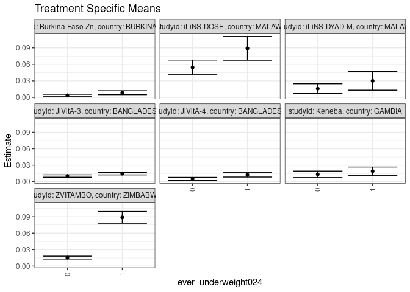

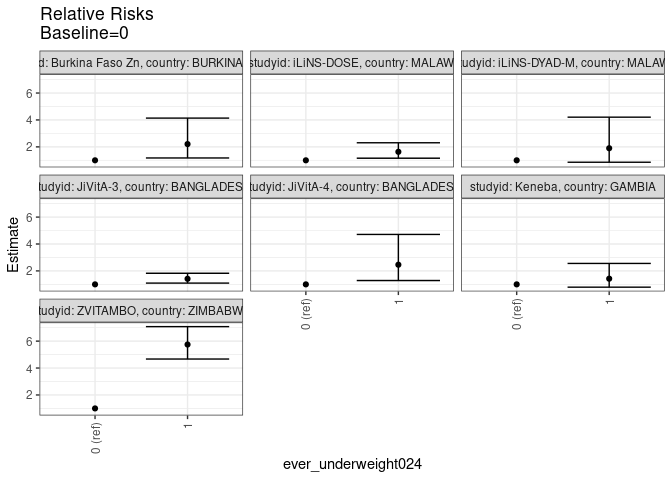

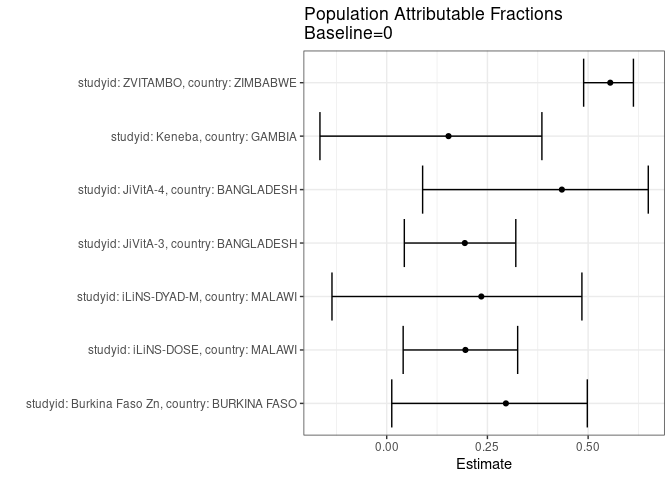

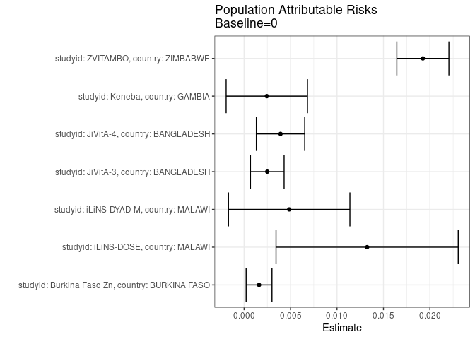

## Results Table

### Parameter: TSM

| studyid | country | intervention_level | baseline_level | estimate | ci_lower | ci_upper |
| --- | --- | --- | --- | --- | --- | --- |
| Burkina Faso Zn | BURKINA FASO | 0 | NA | 0.0038335 | 0.0020655 | 0.0056014 |
| Burkina Faso Zn | BURKINA FASO | 1 | NA | 0.0084564 | 0.0048368 | 0.0120759 |
| iLiNS-DOSE | MALAWI | 0 | NA | 0.0545270 | 0.0411780 | 0.0678760 |
| iLiNS-DOSE | MALAWI | 1 | NA | 0.0890335 | 0.0675470 | 0.1105201 |
| iLiNS-DYAD-M | MALAWI | 0 | NA | 0.0158173 | 0.0069592 | 0.0246753 |
| iLiNS-DYAD-M | MALAWI | 1 | NA | 0.0300180 | 0.0130569 | 0.0469790 |
| JiVitA-3 | BANGLADESH | 0 | NA | 0.0103801 | 0.0082564 | 0.0125039 |
| JiVitA-3 | BANGLADESH | 1 | NA | 0.0146699 | 0.0123738 | 0.0169659 |
| JiVitA-4 | BANGLADESH | 0 | NA | 0.0050974 | 0.0021855 | 0.0080093 |
| JiVitA-4 | BANGLADESH | 1 | NA | 0.0125418 | 0.0085352 | 0.0165484 |
| Keneba | GAMBIA | 0 | NA | 0.0134906 | 0.0076441 | 0.0193371 |
| Keneba | GAMBIA | 1 | NA | 0.0191795 | 0.0115943 | 0.0267647 |
| ZVITAMBO | ZIMBABWE | 0 | NA | 0.0154343 | 0.0128250 | 0.0180437 |
| ZVITAMBO | ZIMBABWE | 1 | NA | 0.0887118 | 0.0779362 | 0.0994874 |

### Parameter: E(Y)

| studyid | country | intervention_level | baseline_level | estimate | ci_lower | ci_upper |
| --- | --- | --- | --- | --- | --- | --- |
| Burkina Faso Zn | BURKINA FASO | NA | NA | 0.0054446 | 0.0037404 | 0.0071489 |
| iLiNS-DOSE | MALAWI | NA | NA | 0.0677695 | 0.0563864 | 0.0791525 |
| iLiNS-DYAD-M | MALAWI | NA | NA | 0.0206718 | 0.0124839 | 0.0288597 |
| JiVitA-3 | BANGLADESH | NA | NA | 0.0128766 | 0.0113280 | 0.0144251 |
| JiVitA-4 | BANGLADESH | NA | NA | 0.0090190 | 0.0064698 | 0.0115681 |
| Keneba | GAMBIA | NA | NA | 0.0159363 | 0.0112643 | 0.0206082 |
| ZVITAMBO | ZIMBABWE | NA | NA | 0.0346771 | 0.0313629 | 0.0379914 |

### Parameter: RR

| studyid | country | intervention_level | baseline_level | estimate | ci_lower | ci_upper |
| --- | --- | --- | --- | --- | --- | --- |
| Burkina Faso Zn | BURKINA FASO | 0 | 0 | 1.000000 | 1.0000000 | 1.000000 |
| Burkina Faso Zn | BURKINA FASO | 1 | 0 | 2.205930 | 1.1758394 | 4.138429 |
| iLiNS-DOSE | MALAWI | 0 | 0 | 1.000000 | 1.0000000 | 1.000000 |
| iLiNS-DOSE | MALAWI | 1 | 0 | 1.632835 | 1.1575137 | 2.303342 |
| iLiNS-DYAD-M | MALAWI | 0 | 0 | 1.000000 | 1.0000000 | 1.000000 |
| iLiNS-DYAD-M | MALAWI | 1 | 0 | 1.897798 | 0.8564172 | 4.205471 |
| JiVitA-3 | BANGLADESH | 0 | 0 | 1.000000 | 1.0000000 | 1.000000 |
| JiVitA-3 | BANGLADESH | 1 | 0 | 1.413264 | 1.0949659 | 1.824089 |
| JiVitA-4 | BANGLADESH | 0 | 0 | 1.000000 | 1.0000000 | 1.000000 |
| JiVitA-4 | BANGLADESH | 1 | 0 | 2.460432 | 1.2849080 | 4.711408 |
| Keneba | GAMBIA | 0 | 0 | 1.000000 | 1.0000000 | 1.000000 |
| Keneba | GAMBIA | 1 | 0 | 1.421693 | 0.7906132 | 2.556509 |
| ZVITAMBO | ZIMBABWE | 0 | 0 | 1.000000 | 1.0000000 | 1.000000 |
| ZVITAMBO | ZIMBABWE | 1 | 0 | 5.747690 | 4.6684603 | 7.076410 |

### Parameter: PAR

| studyid | country | intervention_level | baseline_level | estimate | ci_lower | ci_upper |
| --- | --- | --- | --- | --- | --- | --- |
| Burkina Faso Zn | BURKINA FASO | 0 | NA | 0.0016112 | 0.0002208 | 0.0030016 |
| iLiNS-DOSE | MALAWI | 0 | NA | 0.0132425 | 0.0034376 | 0.0230474 |
| iLiNS-DYAD-M | MALAWI | 0 | NA | 0.0048546 | -0.0016793 | 0.0113884 |
| JiVitA-3 | BANGLADESH | 0 | NA | 0.0024964 | 0.0006854 | 0.0043074 |
| JiVitA-4 | BANGLADESH | 0 | NA | 0.0039216 | 0.0013193 | 0.0065238 |
| Keneba | GAMBIA | 0 | NA | 0.0024457 | -0.0019313 | 0.0068226 |
| ZVITAMBO | ZIMBABWE | 0 | NA | 0.0192428 | 0.0164394 | 0.0220462 |

### Parameter: PAF

| studyid | country | intervention_level | baseline_level | estimate | ci_lower | ci_upper |
| --- | --- | --- | --- | --- | --- | --- |
| Burkina Faso Zn | BURKINA FASO | 0 | NA | 0.2959193 | 0.0125694 | 0.4979600 |
| iLiNS-DOSE | MALAWI | 0 | NA | 0.1954053 | 0.0408448 | 0.3250596 |
| iLiNS-DYAD-M | MALAWI | 0 | NA | 0.2348404 | -0.1358500 | 0.4845541 |
| JiVitA-3 | BANGLADESH | 0 | NA | 0.1938736 | 0.0437231 | 0.3204481 |
| JiVitA-4 | BANGLADESH | 0 | NA | 0.4348140 | 0.0891609 | 0.6492956 |
| Keneba | GAMBIA | 0 | NA | 0.1534648 | -0.1656992 | 0.3852429 |
| ZVITAMBO | ZIMBABWE | 0 | NA | 0.5549131 | 0.4888430 | 0.6124432 |